# Homework7

Neeraj Vardhan Buneeti

2024-10-18

## Question 3

```
##             x          y     fitted  residuals
## 1 -0.56047565 -1.9279297 0.08648088 -2.0144106
## 2 -0.23017749  2.1218051 1.02256904  1.0992361
## 3  1.55870831  5.8960167 6.09239696 -0.1963802
## 4  0.07050839  1.1124990 1.87473393 -0.7622350
## 5  0.12928774 -0.6214189 2.04131871 -2.6627376
## 6  1.71506499  7.0028048 6.53552274  0.4672820
```

[figure not shown]

```r
library(ggplot2)
data <- read.csv("HW7-data-1.csv")
model <- lm(y ~ x, data = data)
data$fitted <- fitted (model)
data$residuals <- resid(model)
head (data)
```

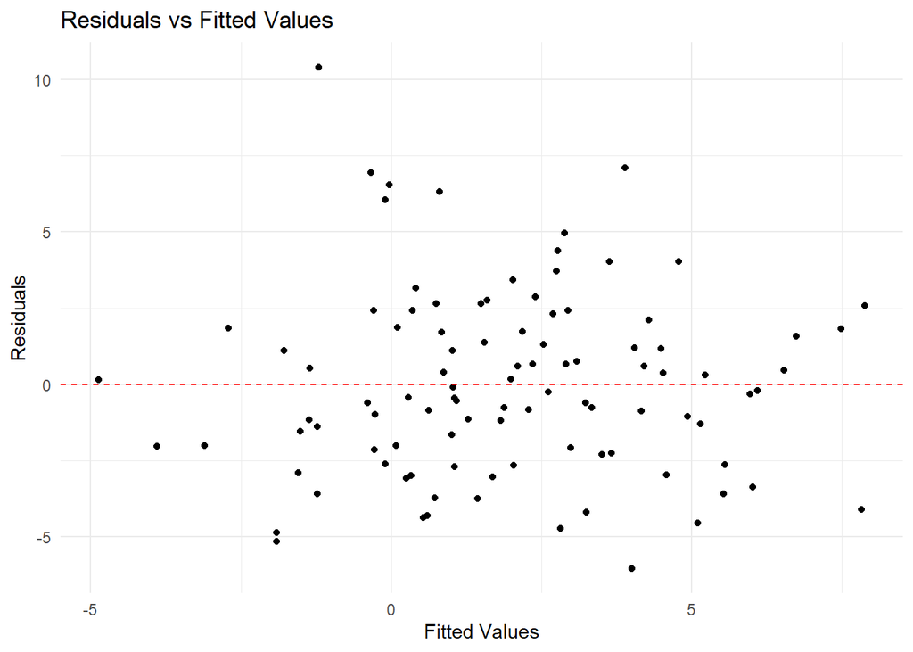

```r
ggplot (data, aes (x = fitted, y = residuals)) +
geom_point() +
geom_hline(yintercept = 0, linetype = "dashed",color = "red") +
  labs(title = "Residuals vs Fitted Values",
x = "Fitted Values",
y = "Residuals") +
theme_minimal()
```

i. The residuals appear to be randomly scattered around the horizontal line at y = 0, without any noticeable pattern, indicating that a linear model is appropriate for representing the relationship between x and y. If the data showed any curvature or trend, it would suggest that a linear model might not be suitable, and a nonlinear relationship could be present.

2. Additionally, if the residuals are evenly spaced across all levels of the fitted values, we can infer that the variance of the residuals is constant, a condition known as homoscedasticity. However, if the spread of the residuals varies significantly, it would indicate a violation of the assumptions of linear regression.

## Question 4

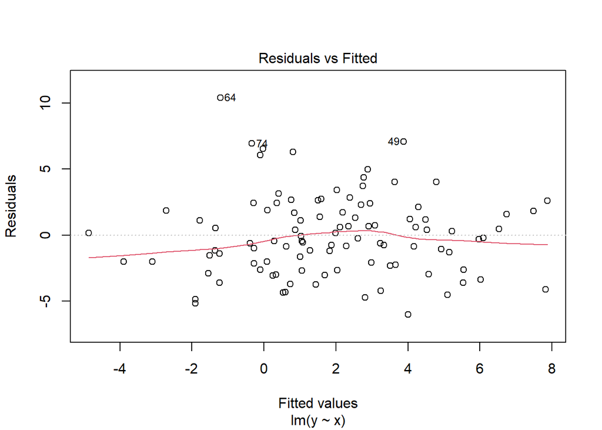

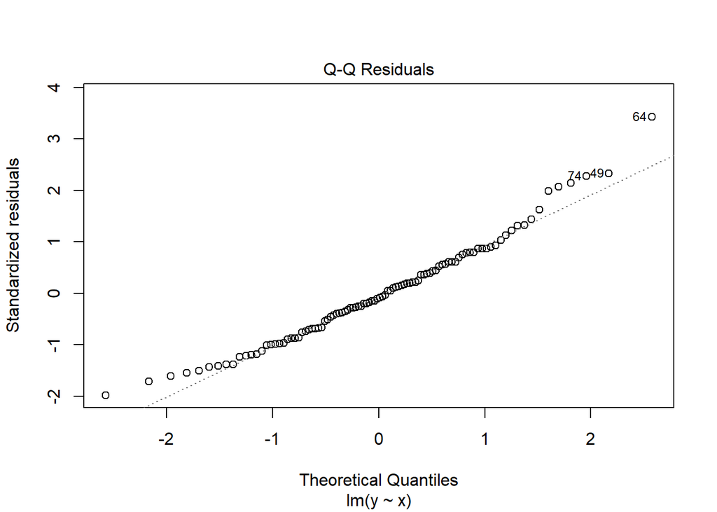

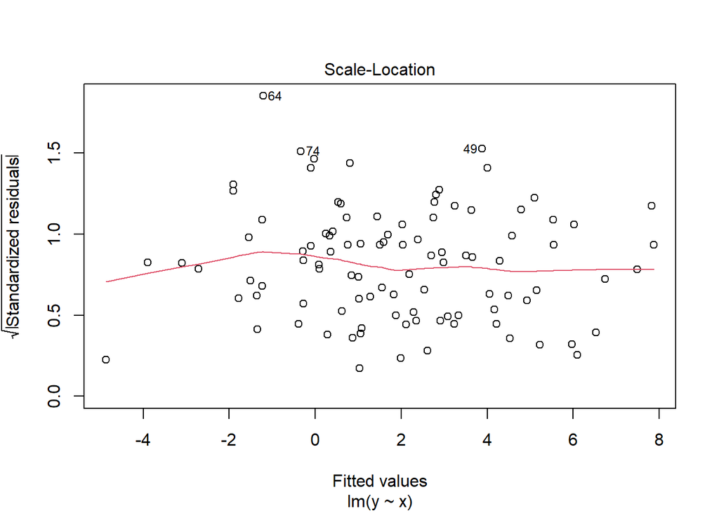

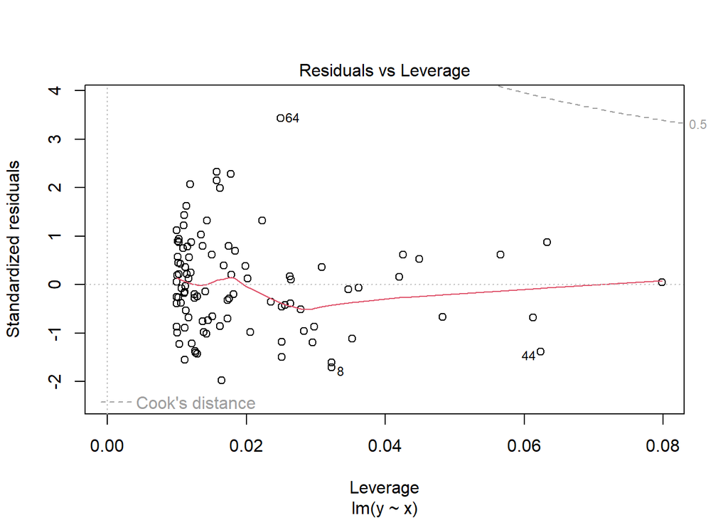

```r
library(ggplot2)
data <- read.csv("HW7-data-1.csv")
model <- lm(y ~ x, data = data)
plot (model)
```

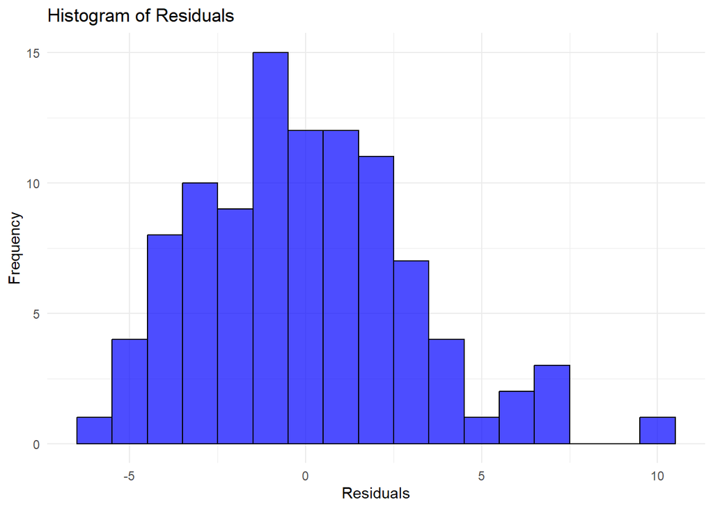

```r
data$fitted <- fitted(model)
data$residuals <- resid(model)
ggplot(data, aes(x = residuals)) +
geom_histogram(binwidth = 1, fill = "blue", color = "black", alpha = 0.7) +
labs (title = "Histogram of Residuals",
x = "Residuals",
y = "Frequency") +
theme_minimal ()
```

The QQ plot and histogram are used to assess the distribution of residuals in a regression model. In a QQ plot, residuals are compared to a normal distribution, and if the points form a straight line, it suggests that the residuals follow a normal distribution. However, deviations, such as skewness or heavy tails, may indicate issues with normality.

The histogram reflects the frequency distribution of the residuals, and a bell-shaped, symmetric curve implies normality. Any asymmetry, on the other hand, suggests a deviation from normality. Evaluating these plots helps determine whether the residuals satisfy the normality assumption, which is important for reliable statistical inference in linear regression.

## Question 5

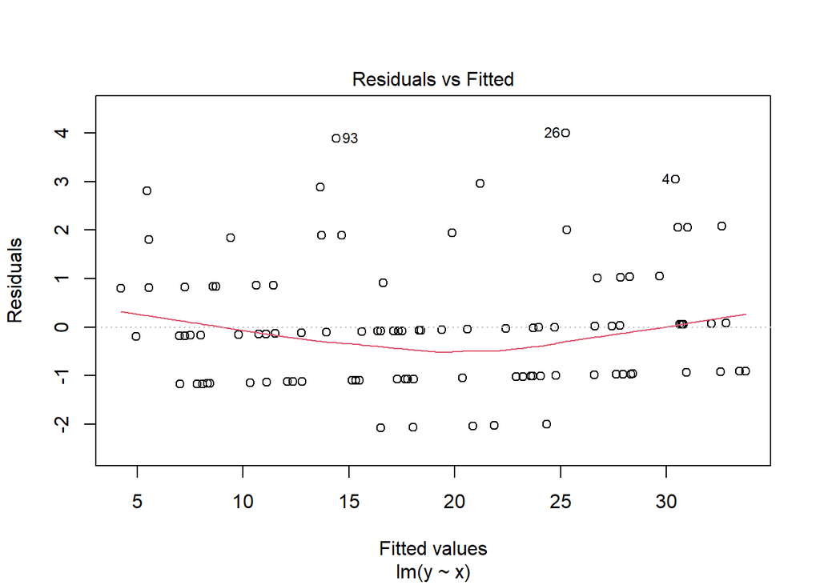

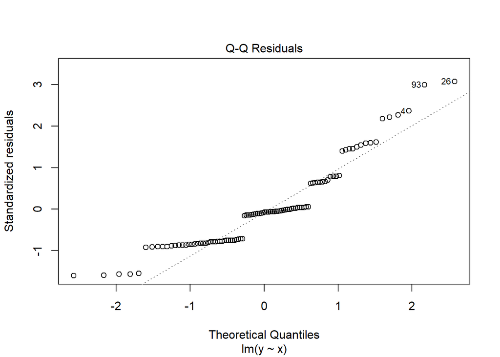

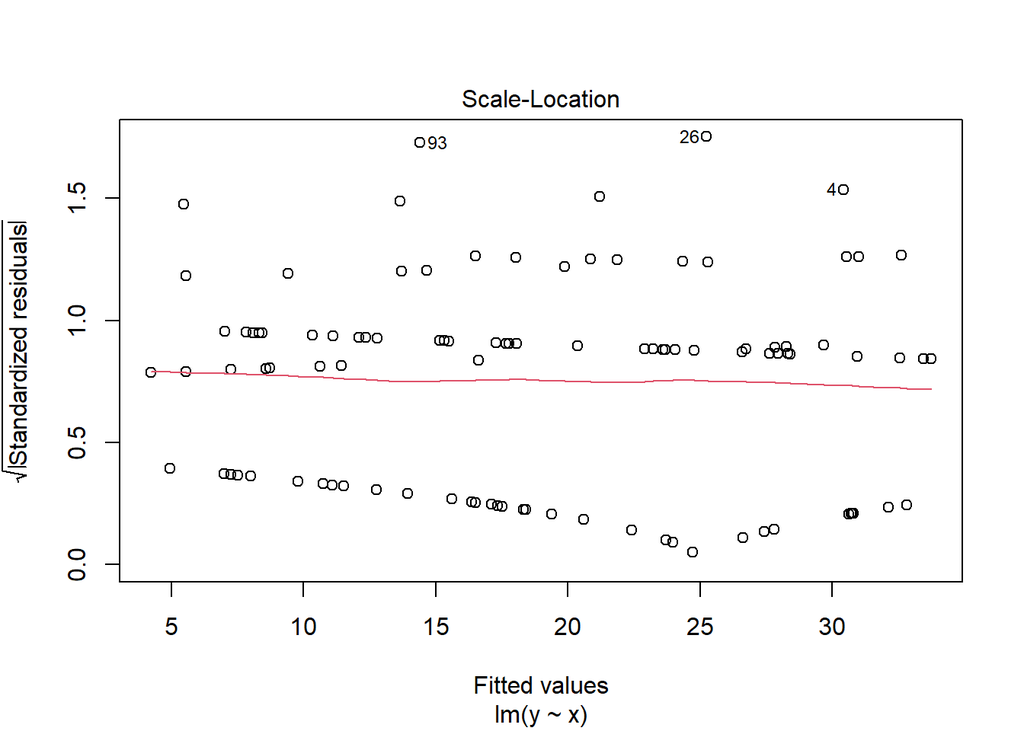

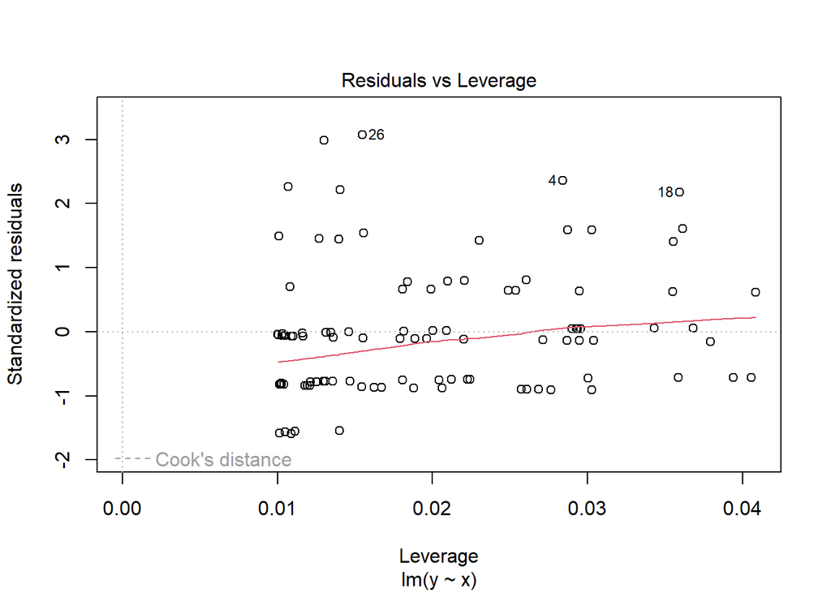

```r
library(ggplot2)
data <- read.csv("HW7-data-2.csv")
model <- lm(y ~ x, data = data)
plot (model)
```

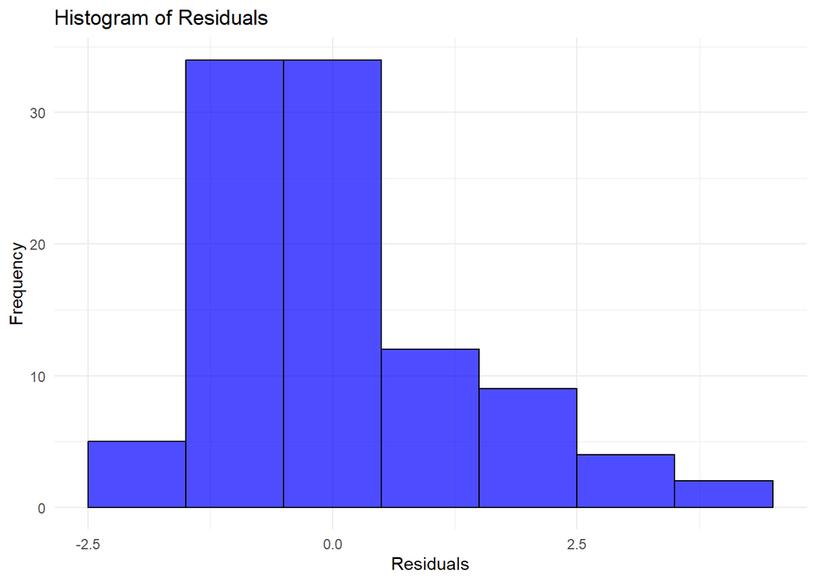

```r
data$fitted <- fitted(model)
data$residuals <- resid(model)
ggplot(data, aes(x = residuals)) +
geom_histogram(binwidth = 1, fill = "blue", color = "black", alpha = 0.7) +
labs (title = "Histogram of Residuals",
x = "Residuals",
y = "Frequency") +
theme_minimal ()
```

We observe from the QQ plot that only a portion of the points align with the diagonal line, indicating that most of the residuals do not follow a normal distribution. Significant deviations of points from this line suggest the presence of outliers.

The histogram helps identify skewness in the distribution, with a concentration of values near zero and a noticeable rightward tail, further confirming that the residuals do not follow a normal distribution.